# Missing Data practical Week 3

Kim Luijken, adapted from work by Valentijn de Jong and Thomas Debray

2022

This practical was developed using R version 4.1.1.

## Introduction

You perform a cohort study on annual influenza vaccine effectiveness. The aim of the study is to assess whether annual influenza vaccination reduces the risk of hospitalisation. The data consist of observations on eligible subjects who did, or did not, receive the annual influenza vaccine. The endpoint in this study is hospitalisation during the influenza epidemic period. Note that the vaccine was not randomly allocated; rather vaccination status may depend on characteristics of the participants in the study.

| Variable | Description | Coding | Meaning |
| --- | --- | --- | --- |
| vacc | Influenza vaccination | 0 | Unvaccinated |
| vacc | Influenza vaccination | 1 | Vaccinated |
| age | Age | Continuous | Years |
| sex | Sex | 0 | Male |
| sex | Sex | 1 | Female |
| cvd | Cardiovascular disease | 0 | Absent |
| cvd | Cardiovascular disease | 1 | Present |
| pulm | Pulmonary disease | 0 | Absent |
| pulm | Pulmonary disease | 1 | Present |
| DM | Diabetus mellitus | 0 | Absent |
| DM | Diabetus mellitus | 1 | Present |
| contact | Number of GP contacts | Discrete | Count |
| hosp | Hospitalisation status | 0 | No hospitalisation |
| hosp | Hospitalisation status | 1 | Hospitalisation |

## Aim of the practical

The aims of the current practical are:

- to get familiar with methods that handle univariate missingness, i.e., missingness in a single variable
- to get familiar with methods that handle multivariate missingness, i.e. missingness in multiple variables

## Preparation

The research question you will address here is whether influenza vaccination affects hospitalisation. As vaccination was not randomized, confounder adjustment is necessary. To investigate the effect of influenza vaccination on risk of hospitalisation, we will fit the following regression model:

```r
formula(hosp ~ vacc + DM + cvd + pulm + I(log(contact)) + age + sex)
```

## Univariate missingness

To learn about imputation methods, we focus on a univariate missingness problem first. To that extent, we load a dataset in which only data on cardiovascular disease is missing.

```r
load("miss.data.uni.RData")
```

**Question 1.** How many observations do we have?

```r
summary(miss.data.uni)
```

```
##       vacc             age              sex              cvd
##  Min.   :0.0000   Min.   : 65.00   Min.   :0.0000   Min.   :0.000
##  1st Qu.:0.0000   1st Qu.: 70.00   1st Qu.:0.0000   1st Qu.:0.000
##  Median :1.0000   Median : 75.00   Median :1.0000   Median :0.000
##  Mean   :0.7404   Mean   : 75.65   Mean   :0.6191   Mean   :0.467
##  3rd Qu.:1.0000   3rd Qu.: 80.00   3rd Qu.:1.0000   3rd Qu.:1.000
##  Max.   :1.0000   Max.   :104.00   Max.   :1.0000   Max.   :1.000
##                                                     NA's   :9793
##       pulm              DM             contact            hosp
##  Min.   :0.0000   Min.   :0.00000   Min.   :  2.00   Min.   :0.00000
##  1st Qu.:0.0000   1st Qu.:0.00000   1st Qu.:  7.00   1st Qu.:0.00000
##  Median :0.0000   Median :0.00000   Median : 12.00   Median :0.00000
##  Mean   :0.1234   Mean   :0.06545   Mean   : 14.75   Mean   :0.00635
##  3rd Qu.:0.0000   3rd Qu.:0.00000   3rd Qu.: 20.00   3rd Qu.:0.00000
##  Max.   :1.0000   Max.   :1.00000   Max.   :146.00   Max.   :1.00000
##
```

```r
str(miss.data.uni)
```

```
## 'data.frame':    40000 obs. of  8 variables:
##  $ vacc   : int  1 1 1 1 1 1 1 1 1 1 ...
##  $ age    : int  66 73 75 76 77 78 80 81 66 67 ...
##  $ sex    : int  0 1 1 1 1 1 1 1 0 0 ...
##  $ cvd    : int  NA 1 1 1 1 1 1 NA 0 0 ...
##  $ pulm   : int  1 0 0 0 0 0 0 0 0 0 ...
##  $ DM     : int  0 0 0 0 0 0 0 0 0 0 ...
##  $ contact: int  27 4 8 7 7 5 9 17 10 13 ...
##  $ hosp   : int  0 0 0 0 0 0 0 0 0 0 ...
```

```r
pct.missing.uni <- round(colMeans(is.na(miss.data.uni)) * 100, 2)
pct.missing.uni
```

```
##    vacc     age     sex     cvd    pulm      DM contact    hosp
##    0.00    0.00    0.00   24.48    0.00    0.00    0.00    0.00
```

*Answer: We have a total of 40000 observations. The missingness on the variables varies from 0% to 24.48%. On average, 3.06% is missing.*

**Question 2.** Do you think the missingness was caused by a MAR or MNAR mechanism? Why?

*Answer: There is no statistical test that can indicate whether data ar MAR of MNAR. The assumption of MAR of MNAR needs to be made by you as a researcher.*

We are now going to perform multiple imputation to impute the missing values of cvd, using the `mice` package.

```r
install.packages("mice")
library(mice)
```

MICE distinguishes between three types of variables: numeric, binary (factor with 2 levels), and categorical (factor with more than 2 levels). Each type has a default imputation method,: predictive mean matching for numeric data, logistic regression for binary data, and polytomous (unordered) regression for categorical data.

Indicate which measurement level each variable has to make sure mice handles them well.

```r
MICE.data.uni <- with(miss.data.uni, data.frame(sex = factor(sex),
                                              age = age,
                                              vacc = factor(vacc),
                                              cvd = factor(cvd),
                                              pulm = factor(pulm),
                                              DM = factor(DM),
                                              contact = contact,
                                              hosp = factor(hosp)))
```

We begin by performing a dry run for the multiple imputation procedure.

```r
set.seed(28102022)

# Configuration of the MICE model
MICE.0.uni <- mice(MICE.data.uni, maxit = 0)
MICE.0.uni
```

```
## Class: mids
## Number of multiple imputations:  5
## Imputation methods:
##      sex      age     vacc      cvd     pulm       DM  contact     hosp
##       ""       ""       "" "logreg"       ""       ""       ""       ""
## PredictorMatrix:
##      sex age vacc cvd pulm DM contact hosp
## sex    0   1    1   1    1  1       1    1
## age    1   0    1   1    1  1       1    1
## vacc   1   1    0   1    1  1       1    1
## cvd    1   1    1   0    1  1       1    1
## pulm   1   1    1   1    0  1       1    1
## DM     1   1    1   1    1  0       1    1
```

**Question 3.** Interpret the output of MICE.0 (use ?mice )

```
+ What does "Imputation methods" tell us? Why is this important?
+ For which variables do you want to impute?
+ Which variables do you want to use as predictors in the imputation model?
+ And which are used by default?
```

- *For each variable in the data set, an imputation model can be supplied. What model is to be used depends on the distribution of the variable. Misspecification of the imputation model may therefore cause implausible values to be imputed.*

### MICE - default

By default, `mice()` will generate 5 imputed datasets and perform 5 iterations in the Gibbs sampler. Please be patient, as this takes a few minutes.

```r
MICE.imp.data.default.uni <- mice(MICE.data.uni, m = 5)
```

Of note, before we analyze the data, it is important to perform checks to inspect the imputation. There are multiple checks to conduct, but as a preliminary illustration, we provide code here to assess whether the Gibbs sampler converged by assessing the trace line plot.

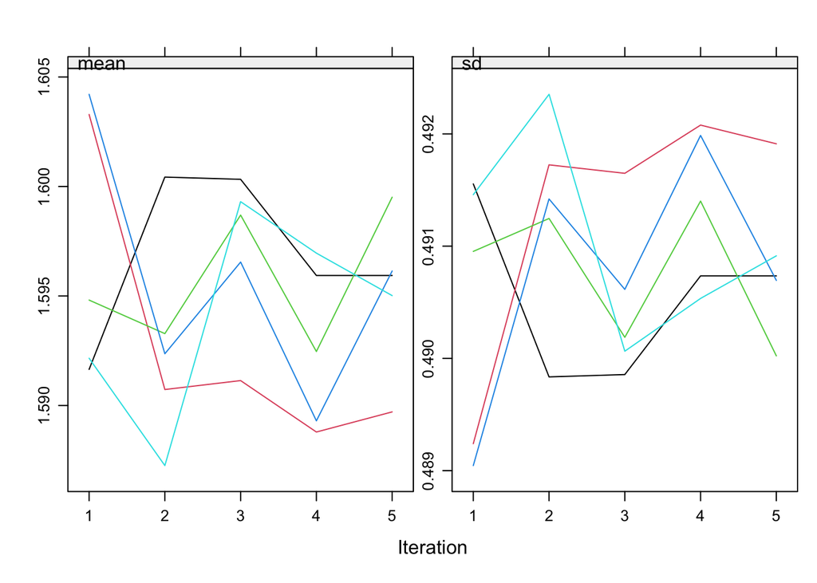

```r
plot(MICE.imp.data.default.uni, y = "cvd", layout = c(2,1))
```

We can now analyze the imputed datasets and store the results. We fit a logistic regression model in each imputed data set, and combine the results using Rubin’s rules. Note that when applying the `with()` statement to `MICE.imp.data.default.uni`, the `glm()` command recognizes this is a dataset with multiple imputations.

```r
# Start the analyses
MIversion1.uni <- with(data = MICE.imp.data.default.uni,
                   exp = glm(hosp ~ vacc + DM + cvd + pulm + I(log(contact)) + age + sex,
                             family = binomial()))

# Use Rubin's rules
pooledEst.uni <- pool(MIversion1.uni)
```

The mice built-in function `pool()` provides information on the pooled regression coefficients (`estimate`), the within-imputation variance (`ubar`), the between-imputation variance (`b`), and the total variance (`t`).

```r
pooledEst.uni
```

```
## Class: mipo    m = 5
##              term m     estimate         ubar            b            t dfcom
## 1     (Intercept) 5 -11.35579315 4.571599e-01 2.981799e-02 0.4929414756 39992
## 2           vacc1 5  -0.41607274 2.095351e-02 8.719042e-04 0.0219997966 39992
## 3             DM1 5   0.40770270 4.142128e-02 3.102954e-04 0.0417936378 39992
## 4            cvd1 5   0.29078936 2.243555e-02 3.534206e-01 0.4465402349 39992
## 5           pulm1 5   0.52362038 2.477383e-02 3.535552e-04 0.0251980913 39992
## 6 I(log(contact)) 5   0.47293331 9.985360e-03 1.786523e-02 0.0314236307 39992
## 7             age 5   0.07053968 7.331203e-05 4.908475e-06 0.0000792022 39992
## 8            sex1 5  -0.76350621 1.703394e-02 3.556412e-04 0.0174607137 39992
##             df          riv      lambda         fmi
## 1   743.929110  0.078269299 0.072587895 0.075071162
## 2  1690.000165  0.049933635 0.047558848 0.048684000
## 3 22185.145332  0.008989448 0.008909357 0.008998693
## 4     4.424636 18.903248445 0.949756945 0.963291091
## 5 10383.391497  0.017125586 0.016837238 0.017026556
## 6     8.588150  2.146970293 0.682234052 0.737077312
## 7   709.373907  0.080343842 0.074368769 0.076967492
## 8  5714.877057  0.025054060 0.024441697 0.024782927
```

## Multivariate missingness

Multivariate missingness has major implications for most imputation methods:

- the covariates that provide information on the missingness mechanism contain missing values themselves;
- this “circular” dependence occurs even given information from other covariables;
- especially with a large number of covariates with missing values and small sample size, collinearity or empty cells occur;
- variables are of different types (e.g., binary, unordered, ordered, continuous), thereby making the application of theoretically convenient models, such as the multivariate normal, theoretically inappropriate;
- imputation can create impossible combinations such as pregnant fathers.

For a description of the missing data patterns, revisit your results from last week’s practical. In this practical, we will use multiple imputation for this data with multivariate missingness

Load the data with multivariate missingness.

```r
load("miss.data.multi.RData") # if the data is in your working directory
load(file.choose()) # if it is not
```

Indicate which measurement level each variable has to make sure mice handles them well.

```r
MICE.data <- with(miss.data.multi, data.frame(sex = factor(sex),
                                              age = age,
                                              vacc = factor(vacc),
                                              cvd = factor(cvd),
                                              pulm = factor(pulm),
                                              DM = factor(DM),
                                              contact = contact,
                                              hosp = factor(hosp)))
```

We begin by performing a dry run for the multiple imputation procedure.

```r
set.seed(28102022)

# Configuration of the MICE model
MICE.0 <- mice(MICE.data, maxit = 0)
MICE.0
```

```
## Class: mids
## Number of multiple imputations:  5
## Imputation methods:
##      sex      age     vacc      cvd     pulm       DM  contact     hosp
##       ""       "" "logreg" "logreg" "logreg" "logreg"    "pmm" "logreg"
## PredictorMatrix:
##      sex age vacc cvd pulm DM contact hosp
## sex    0   1    1   1    1  1       1    1
## age    1   0    1   1    1  1       1    1
## vacc   1   1    0   1    1  1       1    1
## cvd    1   1    1   0    1  1       1    1
## pulm   1   1    1   1    0  1       1    1
## DM     1   1    1   1    1  0       1    1
```

**Question 4.** Interpret the output of MICE.0 (use ?mice )

```
+ What does "Imputation methods" tell us? Why is this important?
+ For which variables do you want to impute?
+ Which variables do you want to use as predictors in the imputation model?
+ And which are used by default?
```

- *For each variable in the data set, an imputation model can be supplied. What model is to be used depends on the distribution of the variable. Misspecification of the imputation model may therefore cause implausible values to be imputed.*

### MICE - default

By default, `mice()` will generate 5 imputed datasets and perform 5 iterations in the Gibbs sampler. Please be patient, as this takes a few minutes.

```r
MICE.imp.data.default <- mice(MICE.data, m = 5)
```

Of note, before we analyze the data, it is important to perform checks to inspect the imputation. There are multiple checks to conduct, but as a preliminary illustration, we provide code here to assess whether the Gibbs sampler converged by assessing the trace line plot.

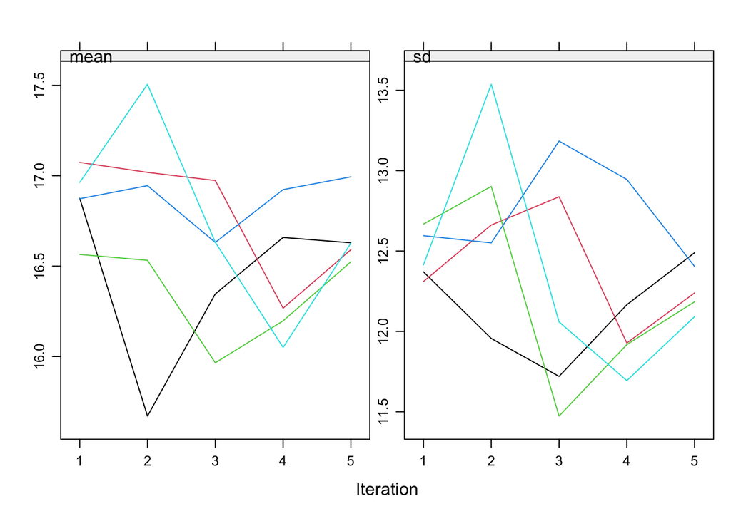

```r
plot(MICE.imp.data.default, y = "contact", layout = c(2,1))
```

We can now analyze the imputed datasets and store the results. We fit a logistic regression model in each imputed data set, and combine the results using Rubin’s rules. Note that when applying the `with()` statement to `MICE.imp.data.default`, the `glm()` command recognizes this is a dataset with multiple imputations.

```r
# Start the analyses
MIversion1 <- with(data = MICE.imp.data.default,
                   exp = glm(hosp ~ vacc + DM + cvd + pulm + I(log(contact)) + age + sex,
                             family = binomial()))

# Use Rubin's rules
pooledEst <- pool(MIversion1)
```

The mice built-in function `pool()` provides information on the pooled regression coefficients (`estimate`), the within-imputation variance (`ubar`), the between-imputation variance (`b`), and the total variance (`t`).

```r
pooledEst
```

```
## Class: mipo    m = 5
##              term m     estimate         ubar            b            t dfcom
## 1     (Intercept) 5 -10.77997316 4.686262e-01 1.849715e-02 4.908228e-01 39992
## 2           vacc1 5  -0.66513088 2.062441e-02 4.777881e-03 2.635787e-02 39992
## 3             DM1 5   0.30160631 4.818488e-02 3.003838e-02 8.423093e-02 39992
## 4            cvd1 5   0.66890092 2.477409e-02 1.744840e-01 2.341549e-01 39992
## 5           pulm1 5   0.89102425 2.299988e-02 2.406457e-02 5.187736e-02 39992
## 6 I(log(contact)) 5   0.31807624 1.016249e-02 7.732850e-03 1.944191e-02 39992
## 7             age 5   0.06622088 7.630833e-05 7.731660e-06 8.558632e-05 39992
## 8            sex1 5  -0.75347596 1.767821e-02 7.178571e-04 1.853963e-02 39992
##            df        riv     lambda        fmi
## 1 1860.550551 0.04736522 0.04522321 0.04624789
## 2   84.309333 0.27799376 0.21752356 0.23544780
## 3   21.820932 0.74807814 0.42794319 0.47403790
## 4    4.996657 8.45160220 0.89419783 0.92065943
## 5   12.899744 1.25554897 0.55664895 0.61241728
## 6   17.544114 0.91310513 0.47728957 0.52817621
## 7  337.158713 0.12158558 0.10840508 0.11364731
## 8 1766.927012 0.04872828 0.04646416 0.04754165
```

Note that we can simply increase the amount of imputed datasets to generate by altering the value for `m`:

```r
mice(MICE.data, m = 10)
```